# Analyse Factorielle Multiple (réduite)

Cette analyse ne garde que les groupes de variables présentant des corrélations entre-elles. Les variables retirées sont :

- Attente face à l’effort
- Normes subjectives
- Leadership
- Region

```r
library(tidyverse)  # Manipulation des données
library(readxl)     # Lecture des fichiers Excel
library(ggpubr)     # Représentations graphiques
library(rstatix)    # Tests statistiques en langage Dplyr
library(FactoMineR) # Analyses en composantes principales
library(factoextra) # Visualisation graphique de l'ACP
library(gtsummary)  # Résumé descriptif des données
library(corrplot)   # Corrélogrammes
library(plotly)     # Graphes intéractifs
library(EFAtools)
```

# Avec les données réduites

```r
data <- read_excel("data/data_ubs.xlsx", sheet = "data_afm")
data$ID <- as.factor(data$ID)
data$Pays <- as.factor(data$Pays)
data$Poste <- as.factor(data$Poste)
data$Region <- as.factor(data$Region)
data$Experience <- as.factor(data$Experience)
data$Age <- as.factor(data$Age)
data$Sexe <- as.factor(data$Sexe)
data$Experience <- as.factor(data$Experience)
data$Type <- as.factor(data$Type)

data <- data %>%
  select(-C2, -C3, -C4.1,   -C4.2, -C4.3, -C4.4, -C4.5, -C4.6, -C4.7, -C4.8, -C4.9,
         -Type, -Pays, -Sexe,
         -AFE1, -AFE2, -AFE4, -AFE5,
         -NSUB1, -NSUB2, -NSUB3, -NSUB4, -NSUB5,
         -LDS1, -LDS2, -LDS3, -LDS4, -LDS5, -LDS6,
         -Region)

data <- column_to_rownames(data, "ID")

dataComp <- data %>%
  drop_na()

dataComp
```

|  | Poste | Experience | Age | AFP1 | AFP2 | AFP3 | AFP4 | AFP5 | AFP6 | CF1 | CF2 | CF3 | CF4 | CF5 | CF6 | CF7 | CF8 | IEIP1 | IEIP2 | IEIP3 | IEIP4 | INTU1 | MOT1 | MOT21 | MOT3 | MOT4 | MOT5 | MOT6 | MOT7 | … |
| --- | --- | --- | --- | --- | --- | --- | --- | --- | --- | --- | --- | --- | --- | --- | --- | --- | --- | --- | --- | --- | --- | --- | --- | --- | --- | --- | --- | --- | --- | --- |
| FR7 | Armateur et patron-pecheur | Plus de 20 ans | 45-54 | 3 | 2 | 5 | 5 | 5 | 3 | 5 | 1 | 5 | 5 | 5 | 4 | 4 | 4 | 5 | 3 | 3 | 2 | 5 | 3 | 5 | 5 | 3 | 5 | 5 | 5 | … |
| FR9 | Armateur et patron-pecheur | Plus de 20 ans | 55-64 | 4 | 5 | 3 | 4 | 2 | 3 | 4 | 2 | 5 | 4 | 4 | 3 | 4 | 4 | 5 | 4 | 2 | 4 | 4 | 3 | 4 | 4 | 2 | 4 | 4 | 4 | … |
| FR10 | Matelot | Entre 10 et 15 ans | 25-34 | 3 | 4 | 5 | 4 | 4 | 4 | 4 | 4 | 4 | 5 | 4 | 4 | 4 | 4 | 4 | 4 | 4 | 3 | 4 | 4 | 4 | 4 | 4 | 4 | 5 | 5 | … |
| FR16 | Patron-pecheur | Plus de 20 ans | 45-54 | 4 | 5 | 5 | 5 | 5 | 4 | 5 | 2 | 4 | 5 | 4 | 5 | 2 | 3 | 4 | 4 | 4 | 2 | 4 | 3 | 4 | 4 | 3 | 4 | 5 | 4 | … |
| FR17 | Armateur et patron-pecheur | Entre 15 et 20 ans | 55-64 | 4 | 3 | 4 | 5 | 5 | 4 | 5 | 5 | 4 | 5 | 5 | 3 | 5 | 5 | 5 | 5 | 5 | 1 | 4 | 5 | 5 | 4 | 5 | 4 | 5 | 5 | … |
| FR19 | Patron-pecheur | Plus de 20 ans | 55-64 | 3 | 3 | 4 | 5 | 5 | 3 | 2 | 3 | 5 | 5 | 5 | 5 | 4 | 4 | 4 | 5 | 5 | 4 | 4 | 3 | 4 | 5 | 4 | 5 | 5 | 4 | … |
| FR20 | Armateur et patron-pecheur | Entre 15 et 20 ans | 25-34 | 4 | 3 | 4 | 4 | 4 | 4 | 4 | 2 | 3 | 4 | 4 | 2 | 3 | 4 | 4 | 4 | 4 | 4 | 4 | 3 | 4 | 3 | 3 | 3 | 5 | 4 | … |
| FR25 | Autres | Plus de 20 ans | 35-44 | 5 | 4 | 4 | 5 | 5 | 4 | 5 | 2 | 2 | 5 | 4 | 3 | 4 | 2 | 4 | 5 | 4 | 5 | 3 | 2 | 5 | 5 | 3 | 4 | 5 | 5 | … |
| FR27 | Armateur et patron-pecheur | Entre 10 et 15 ans | 35-44 | 3 | 3 | 3 | 5 | 5 | 3 | 4 | 2 | 3 | 5 | 4 | 5 | 3 | 3 | 4 | 4 | 4 | 4 | 3 | 3 | 4 | 4 | 4 | 3 | 5 | 4 | … |
| FR28 | Patron-pecheur | Entre 10 et 15 ans | 18-24 | 2 | 2 | 4 | 3 | 4 | 3 | 4 | 3 | 4 | 5 | 5 | 3 | 4 | 4 | 5 | 4 | 3 | 5 | 4 | 3 | 3 | 4 | 4 | 4 | 4 | 2 | … |

[output cut: 123 more lines]

## Corrélations

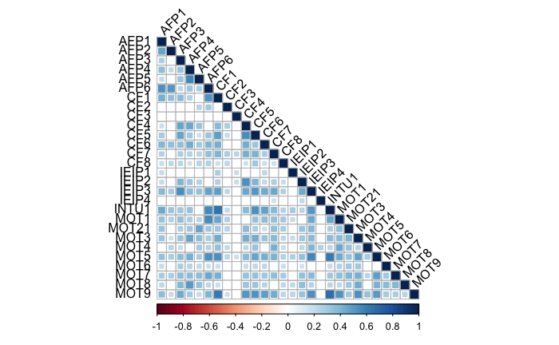

```r
dataComp %>%
  select(where(is.numeric)) %>%
  cor_mat() %>%
  cor_plot(method = "square", type = "lower", insignificant = "blank")
```

# MFA

```r
res.mfa <- MFA(dataComp,
               group = c(1, 1, 1, 6, 8, 4, 1, 9),
               type = c("n", "n", "n", "s", "s", "s", "s", "s"),
               name.group = c("Poste", "Experience", "Age", "AFP", "CF", "IEIP", "INTU", "MOT"),
               graph = F
               )

print(res.mfa)
```

```
**Results of the Multiple Factor Analysis (MFA)**
The analysis was performed on 133 individuals, described by 31 variables
*Results are available in the following objects :

   name                 description
1  "$eig"               "eigenvalues"
2  "$separate.analyses" "separate analyses for each group of variables"
3  "$group"             "results for all the groups"
4  "$partial.axes"      "results for the partial axes"
5  "$inertia.ratio"     "inertia ratio"
6  "$ind"               "results for the individuals"
7  "$quanti.var"        "results for the quantitative variables"
8  "$quali.var"         "results for the categorical variables"
9  "$summary.quanti"    "summary for the quantitative variables"
10 "$summary.quali"     "summary for the categorical variables"
11 "$global.pca"        "results for the global PCA"
```

```r
bartlett.test(dataComp %>% select(where(is.numeric)))
```

```
    Bartlett test of homogeneity of variances

data:  dataComp %>% select(where(is.numeric))
Bartlett's K-squared = 275.45, df = 27, p-value < 2.2e-16
```

```r
KMO(dataComp %>% select(where(is.numeric)))
```

```
ℹ 'x' was not a correlation matrix. Correlations are found from entered raw data.
```

```
── Kaiser-Meyer-Olkin criterion (KMO) ───────────────────────────────────────────────────────────────────────────────

✔ The overall KMO value for your data is meritorious.
  These data are probably suitable for factor analysis.

  Overall: 0.867

  For each variable:
 AFP1  AFP2  AFP3  AFP4  AFP5  AFP6   CF1   CF2   CF3   CF4   CF5   CF6   CF7   CF8 IEIP1 IEIP2 IEIP3 IEIP4 INTU1
0.863 0.727 0.862 0.844 0.744 0.858 0.934 0.767 0.536 0.850 0.921 0.896 0.926 0.888 0.658 0.878 0.932 0.428 0.912
 MOT1 MOT21  MOT3  MOT4  MOT5  MOT6  MOT7  MOT8  MOT9
0.859 0.868 0.895 0.763 0.934 0.876 0.927 0.820 0.902
```

## Valeurs propres

La valeur propre est une mesure de l’importance d’un facteur. Elle correspond au rapport entre la variance expliquée par le facteur et la variance totale des données. Plus la valeur propre d’un facteur est élevée, plus le facteur explique de variance dans les données et donc plus il est important.

Les valeurs propres sont généralement présentées sous forme de pourcentage, de manière à ce qu’elles puissent être comparées entre elles. *Par exemple, si le premier facteur explique 40% de la variance totale des données et que le second facteur explique 20% de la variance, on peut dire que le premier facteur est deux fois plus important que le second.*

```r
eig.val <- get_eigenvalue(res.mfa)
head(eig.val, 20)
```

```
       eigenvalue variance.percent cumulative.variance.percent
Dim.1   3.7071962        16.096590                    16.09659
Dim.2   2.1348941         9.269678                    25.36627
Dim.3   1.6120066         6.999308                    32.36558
Dim.4   1.3762402         5.975614                    38.34119
Dim.5   1.2601545         5.471572                    43.81276
Dim.6   1.2258569         5.322652                    49.13541
Dim.7   1.0789476         4.684774                    53.82019
Dim.8   0.9581867         4.160432                    57.98062
Dim.9   0.9477533         4.115131                    62.09575
Dim.10  0.8064789         3.501719                    65.59747
Dim.11  0.7863476         3.414309                    69.01178
Dim.12  0.7085166         3.076369                    72.08815
Dim.13  0.6484629         2.815616                    74.90377
Dim.14  0.5637338         2.447724                    77.35149
Dim.15  0.4892546         2.124336                    79.47582
Dim.16  0.4728935         2.053297                    81.52912
Dim.17  0.3954972         1.717243                    83.24636
Dim.18  0.3525597         1.530809                    84.77717
Dim.19  0.3202163         1.390375                    86.16755
Dim.20  0.3139037         1.362965                    87.53051
```

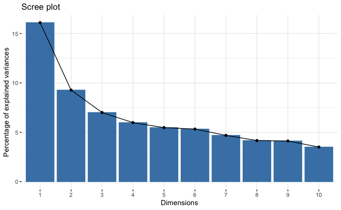

```r
fviz_screeplot(res.mfa)
```

Il faudrait au moins 12 dimensions pour expliquer plus de 70% de la variance. Les analyses qui suivront ne pourront d’être interprétées comme expliquant **25.37% de la variance**.

## Contribution aux dimensions

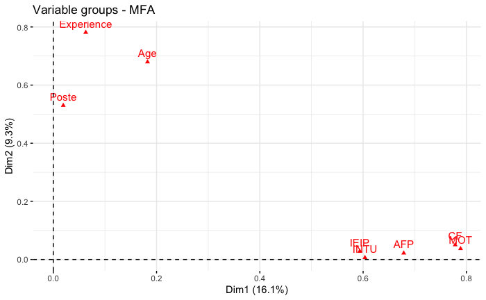

```r
group <- get_mfa_var(res.mfa, "group")

fviz_mfa_var(res.mfa, "group")
```

Le graphique ci-dessus illustre la corrélation entre les groupes et les dimensions.

Nous pouvons remarquer que la dimension 2 représentée par l’axe des ordonnées est constitué des variables catégorielles tandis que la dimension 1 en abscisse est formée principalement pour les variables suivantes :

- Motivation
- Conditions facilitantes
- Attente face à la performance
- Intention d’adoption
- Image espérée et identité

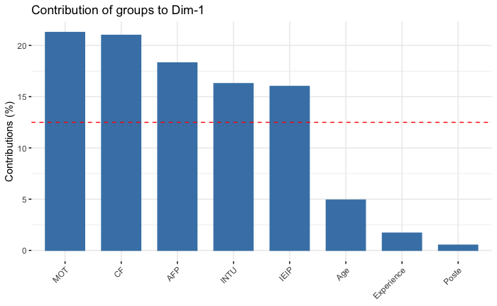

```r
# Contribution à la première dimension
fviz_contrib(res.mfa, "group", axes = 1)
```

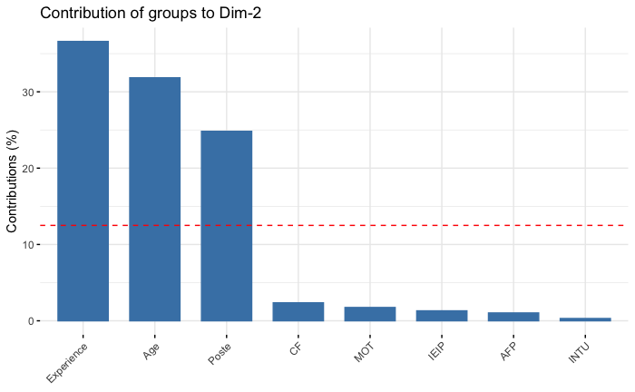

```r
# Contribution à la deuxième dimension
fviz_contrib(res.mfa, "group", axes = 2)
```

### Variables quantitatives

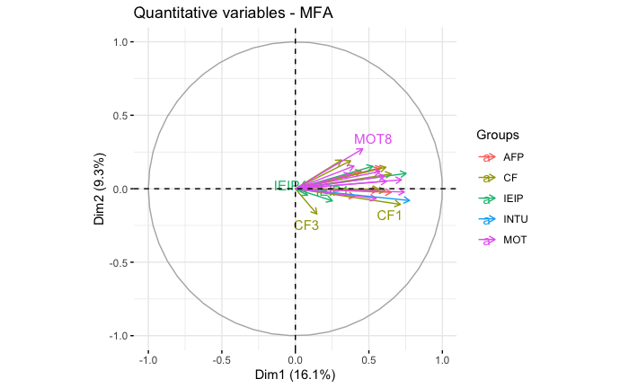

```r
quanti.var <- get_mfa_var(res.mfa, "quanti.var")

fviz_mfa_var(res.mfa, "quanti.var", repel = T)
```

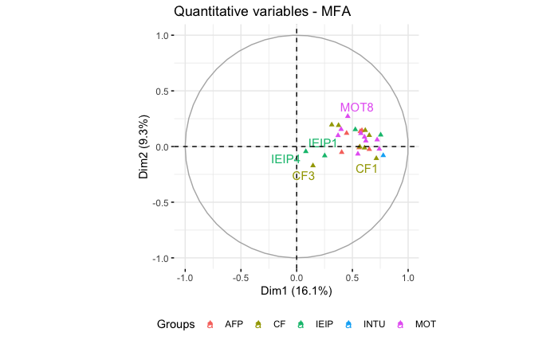

```r
fviz_mfa_var(res.mfa, "quanti.var", repel = T, geom = c("point", "text"), legend = "bottom")
```

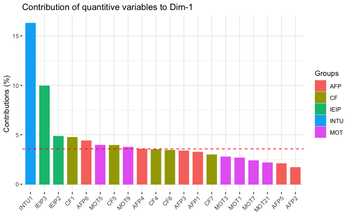

```r
fviz_contrib (res.mfa, choice = "quanti.var", axes = 1, top = 20)
```

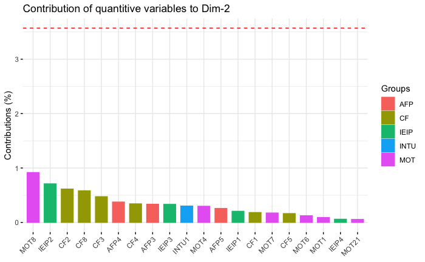

```r
fviz_contrib (res.mfa, choice = "quanti.var", axes = 2, top = 20)
```

## Individus

### Contribution

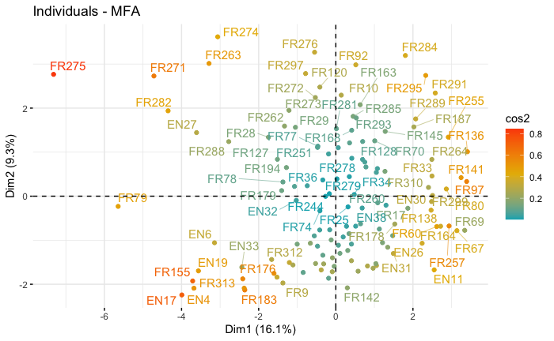

```r
ind <- get_mfa_ind(res.mfa)

fviz_mfa_ind(res.mfa, col.ind = "cos2",
             gradient.cols = c("#00AFBB", "#E7B800", "#FC4E07"),
             repel = T)
```

### Poste

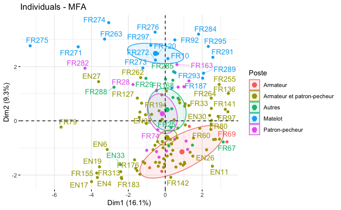

```r
fviz_mfa_ind(res.mfa,
             habillage = "Poste", # color by groups
             addEllipses = TRUE, ellipse.type = "confidence",
             repel = TRUE
             )
```

### Expérience

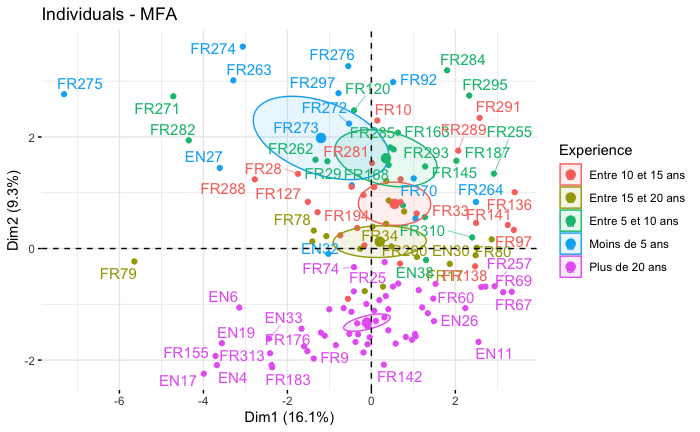

```r
fviz_mfa_ind(res.mfa,
             habillage = "Experience", # color by groups
             addEllipses = TRUE, ellipse.type = "confidence",
             repel = TRUE
             )
```

### Age

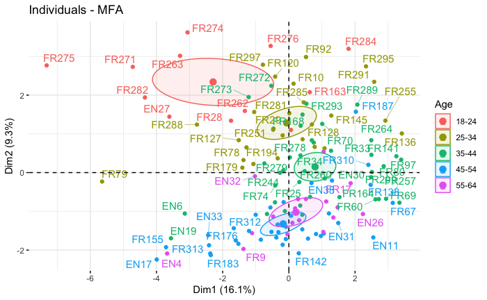

```r
fviz_mfa_ind(res.mfa,
             habillage = "Age", # color by groups
             addEllipses = TRUE, ellipse.type = "confidence",
             repel = TRUE
             )
```